# Using Artificial Neural Network to Classify Music Genre

## Normalizing Spectrogram Images for Model Training

After processing and labeling our spectrogram images, the next crucial step before feeding them into our neural network is normalization. Normalization is a preprocessing technique used to standardize the range of pixel values in images. It helps in speeding up the convergence of the model by ensuring that each input parameter (pixel, in this case) has a similar data distribution

Normalization involves adjusting the range of pixel values such that they are centered around zero. For color images represented in a 0-255 range, we can scale them to a -1 to 1 range. Here’s how we achieve this with our dataset: (https://www.facebook.com/jason.brownlee.39, 2019) In this step, each pixel value in the image is divided by 127.5 (half of 255, the maximum pixel value for an 8-bit image) and then subtracted by 1. This transformation scales our pixel values to lie within the -1 to 1 range.

#### Reshaping for PyTorch Compatibility

PyTorch, like many deep learning frameworks, expects image data to be in a specific shape, specifically in the format of `(N, C, H, W)`:

- **N**: Number of images in the batch.
- **C**: Number of channels in the image (e.g., 3 for RGB).
- **H**: Height of the image.
- **W**: Width of the image.

Our current image array might not follow this structure, so we need to transpose the dimensions to fit PyTorch’s expectation:

This line of code rearranges the axes of our image array to match the `(N, C, H, W)` format, ensuring that our data is ready for model training.

```python
# Normalize each image in the array
normalized_images = np.array([image / 127.5 - 1 for image, _ in images_data], dtype=float)
normalized_images = normalized_images.transpose(0, 3, 1, 2)
```

```python
import plotly.graph_objects as go

# Convert tensor to numpy array and remove the channel dimension
data = normalized_images[0].mean(axis=0)

# Create a heatmap
fig = go.Figure(data=go.Heatmap(
    z=data,
    colorscale='Viridis',  # You can choose other color scales
))

# Update layout (optional)
fig.update_layout(
    title='Normalised spectogram Tensor Visualization',
    xaxis_title='Width',
    yaxis_title='Height'
)
fig.update_yaxes(autorange="reversed")
# Show plot
fig.show()
```

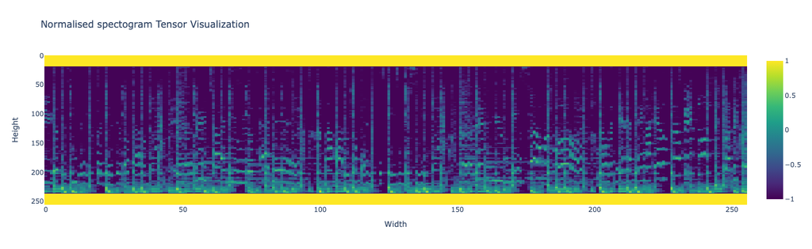

```python
label_encoder = LabelEncoder()
y_encoded_predictors = label_encoder.fit_transform(labels)
```

```python
from sklearn.model_selection import train_test_split

X_train, X_test, y_train, y_test = train_test_split(normalized_images, y_encoded_predictors, test_size=0.2, shuffle=True)
```

```python
X_train_tensor = torch.FloatTensor(X_train)
y_train_tensor = torch.LongTensor(y_train)

X_test_tensor = torch.FloatTensor(X_test)
y_test_tensor = torch.LongTensor(y_test)

train_dataset = TensorDataset(X_train_tensor, y_train_tensor)
test_dataset = TensorDataset(X_test_tensor, y_test_tensor)

train_loader = DataLoader(dataset=train_dataset, batch_size=64, shuffle=False)
test_loader = DataLoader(dataset=test_dataset, batch_size=64, shuffle=False)
```

To enhance our music genre classification model, we're implementing a deep learning architecture known for its robustness and efficiency: the Residual Network (ResNet). ResNets are pivotal in the field of deep learning for their ability to train very deep networks through the introduction of skip connections. These connections help mitigate the vanishing gradient problem, allowing for deeper network architectures without a loss in performance.

#### Understanding the ResNet Architecture

A ResNet model comprises several layers, including convolutional layers, batch normalization, ReLU activations, and, most importantly, residual blocks that incorporate skip connections. These connections enable the network to learn identity functions, ensuring that deeper layers can perform at least as well as shallower ones, thus eliminating the degradation problem.

#### Understanding Model Definition in PyTorch

- **Base Class**: All custom models in PyTorch are defined by subclassing `nn.Module`, which provides essential functionality for model training.
- **Initialization and Forward Pass**: Within this subclass, you typically define two key functions:
  - `__init__`: Here, you specify the layers and components of your model.
  - `forward`: This function outlines how data flows through your model, determining the order of layer execution.
  - `_make_layer` method constructs each layer of the ResNet, dynamically adjusting for channel size and stride as needed, and applying downsampling where necessary to align feature map dimensions.

#### PyTorch Layer Types

- **Convolutional Layers** (`nn.Conv2d`): Applies convolution, taking input and output channels, kernel size, stride, and padding as parameters.
- **Batch Normalization** (`nn.BatchNorm2d`): Normalizes the output from convolutional layers.
- **Activation Functions** (`nn.ReLU`): Applies the ReLU activation function.
- **Pooling Layers** (`nn.MaxPool2d`): Performs max pooling with the specified kernel size.
- **Dropout** (`nn.Dropout`): Introduces dropout in the network with a given probability.
- **Fully Connected Layers** (`nn.Linear`): Represents dense layers in the network.
- **Sequential Containers** (`nn.Sequential`): Groups layers and operations into a single module.

#### The Residual Block

At the heart of ResNet is the Residual Block, designed to allow skip connections that help the gradient flow through the network: Each block includes two convolutional layers with batch normalization and ReLU activation, followed by a skip connection that adds the input of the block to its output:

#### Constructing the ResNet Model

With the `ResidualBlock` defined, we construct the ResNet architecture by stacking these blocks and incorporating convolutional, pooling, and fully connected layers for classification:

This structure allows the network to learn residual functions with reference to the layer inputs, facilitating the training of deeper networks.

#### Assembling the ResNet Model

We define the `ResNet` class to assemble our network. It starts with an initial convolutional layer, followed by a sequence of residual blocks organized into layers. Each layer changes the number of channels and applies downsampling to reduce the spatial dimensions of the feature maps:

# References

This Res net architecture code is adapted from ["Writing ResNet from Scratch in PyTorch"](https://blog.paperspace.com/writing-resnet-from-scratch-in-pytorch/)

```python
class ResidualBlock(nn.Module):
    def __init__(self, in_channels, out_channels, stride = 1, downsample = None):
        super(ResidualBlock, self).__init__()
        self.conv1 = nn.Sequential(
                        nn.Conv2d(in_channels, out_channels, kernel_size = 3, stride = stride, padding = 1),
                        nn.BatchNorm2d(out_channels),
                        nn.ReLU())
        self.conv2 = nn.Sequential(
                        nn.Conv2d(out_channels, out_channels, kernel_size = 3, stride = 1, padding = 1),
                        nn.BatchNorm2d(out_channels))
        self.downsample = downsample
        self.relu = nn.ReLU()
        self.out_channels = out_channels

    def forward(self, x):
        residual = x
        out = self.conv1(x)
        out = self.conv2(out)
        if self.downsample:
            residual = self.downsample(x)
        out += residual
        out = self.relu(out)
        return out


class ResNet(nn.Module):
    def __init__(self, block, layers, num_classes=10):
        super(ResNet, self).__init__()
        self.inplanes = 64
        self.conv1 = nn.Sequential(
            nn.Conv2d(3, 64, kernel_size=7, stride=2, padding=3),
            nn.BatchNorm2d(64),
            nn.ReLU())
        self.maxpool = nn.MaxPool2d(kernel_size=3, stride=2, padding=1)
        self.layer0 = self._make_layer(block, 64, layers[0], stride=1)
        self.layer1 = self._make_layer(block, 128, layers[1], stride=2)
        self.layer2 = self._make_layer(block, 256, layers[2], stride=2)
        self.layer3 = self._make_layer(block, 512, layers[3], stride=2)
        self.pool = nn.AdaptiveMaxPool2d((1, 1))
        self.fc = nn.Linear(512, 10)


    def _make_layer(self, block, planes, blocks, stride=1):
        downsample = None
        if stride != 1 or self.inplanes != planes:
            downsample = nn.Sequential(
                nn.Conv2d(self.inplanes, planes, kernel_size=1, stride=stride),
                nn.BatchNorm2d(planes),
            )
        layers = []
        layers.append(block(self.inplanes, planes, stride, downsample))
        self.inplanes = planes
        for i in range(1, blocks):
            layers.append(block(self.inplanes, planes))
        return nn.Sequential(*layers)

    def forward(self, x):
        x = self.conv1(x)
        x = self.maxpool(x)
        x = self.layer0(x)
        x = self.layer1(x)
        x = self.layer2(x)
        x = self.layer3(x)
        x = self.pool(x)
        x = x.view(x.size(0), -1)
        x_pooled=x

        x = self.fc(x)
        return x , x_pooled
```

##### ResNet Architecture

Our ResNet model starts with an initial convolutional layer, followed by the MaxPooling layer to reduce the spatial dimensions early on. Subsequently, we construct the main body of ResNet using repetitive blocks of `ResidualBlock`, varying in size according to the `layers` argument (e.g., `[3, 4, 6, 3]` for ResNet34):

This structure is highly modular, because of the `_make_layer` helper function, which assembles layers of `ResidualBlock` instances with optional downsampling.

With the model constructed, the next steps involve training it on our preprocessed spectrogram dataset, optimizing its parameters, and evaluating its performance on classifying music genres.

```python
model=ResNet(ResidualBlock, [3, 4, 6, 3])
loss_function = nn.CrossEntropyLoss()
optimizer = Adam(model.parameters(), lr=0.001)
```

# Training

```python
checkpoint = torch.load("model_cnn_dict.pth",map_location=torch.device('cpu'))
model.load_state_dict(checkpoint)
```

## Results

- Training Accuracy on test data: 77%
- Final Loss value: 0.001

### Transition to a ResNet Architecture: Insights and Outcomes

#### Results and Analysis

After training the ResNet model on the spectrogram-based dataset, we observed an accuracy of 77% on the test data. While this is a modest improvement over the 76.5% achieved with the previous MLP architecture, it represents a critical insight into the capabilities and limitations of using deep learning for music genre classification within our dataset's context.

- **Loss Reduction**: The model achieved a minimal loss of 0.001, indicating effective learning and optimization of weights to fit the training data as closely as possible.
- **Insights on Limitations**: Despite the advanced architecture, the marginal improvement in accuracy highlights inherent challenges in genre classification, possibly related to the dataset's diversity, quality of genre labels, or the complexity of distinguishing musical genres based on audio characteristics alone.

#### Conclusion

The transition to a ResNet architecture underscored the potential and limitations of deep learning in music genre classification. While we saw a slight increase in accuracy, it's evident that achieving significant breakthroughs may require exploring additional strategies. These could include data augmentation, exploring alternative architectures, or incorporating additional context or metadata into the classification process.

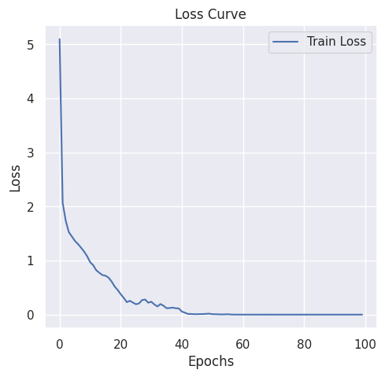

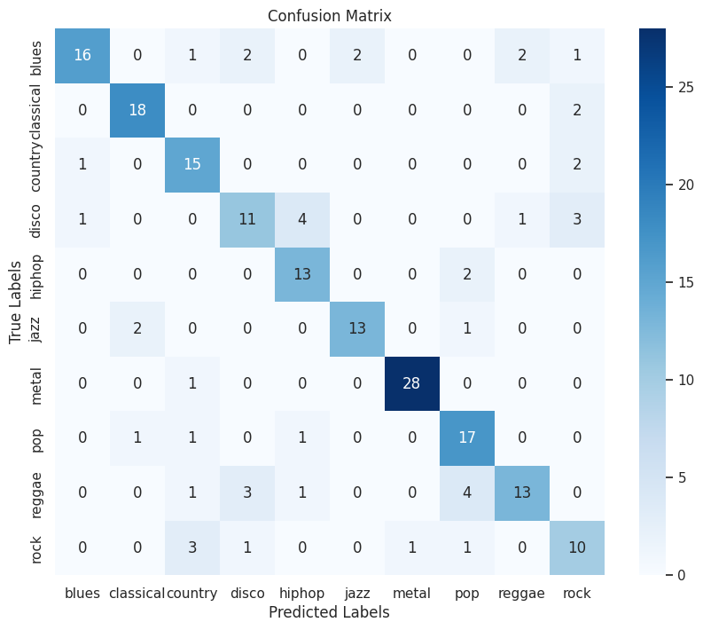

# t-SNE visualisation

t-SNE (t-Distributed Stochastic Neighbor Embedding) is a machine learning algorithm for dimensionality reduction that is particularly well-suited for visualizing high-dimensional data. It works by converting similarities between data points into joint probabilities and then minimizing the divergence between these probabilities in a lower-dimensional space, typically two or three dimensions. This process allows t-SNE to effectively group similar data points together and separate dissimilar ones, making it a powerful tool for exploring and visualizing the underlying patterns and clusters within complex datasets. Due to its ability to reveal the structure at many scales, t-SNE is widely used in exploratory data analysis, especially in fields like bioinformatics, image processing, and speech analysis.

Here we will show how to visually explore the distribution of music features in a two-dimensional space using t-SNE (t-Distributed Stochastic Neighbor Embedding). This technique is particularly useful in music genre classification tasks, allowing us to observe how well different genres are separated based on their audio features.

### Step 1: Import t-SNE from Scikit-Learn

Begin by importing the `TSNE` class from the `sklearn.manifold` module. t-SNE is a non-linear technique for dimensionality reduction that is particularly well suited for the visualization of high-dimensional datasets.

### Step 3: Visualize the Results with a Scatter Plot

After obtaining the 2D embeddings from t-SNE, use Seaborn's scatter plot functionality to visualize the data points. Each point represents a song, colored by its genre to highlight the separation between different music genres.

This visualization offers insights into the natural clustering of songs by genre based on their features, providing a powerful exploratory tool for understanding the effectiveness of your feature set in music genre classification tasks.

### Reference

Adapted from ["Using T-SNE in Python to Visualize High-Dimensional Data Sets"](https://builtin.com/data-science/tsne-python)

```python
full_dataset = TensorDataset(torch.FloatTensor(normalized_images),torch.LongTensor(y_encoded_predictors))
full_data_loader=DataLoader(dataset=full_dataset, batch_size=64, shuffle=False)
```

```python
import matplotlib.pyplot as plt
from sklearn.manifold import TSNE

features = []
labels_list = []

model.eval()  # Set the model to evaluation mode
with torch.no_grad():
    correct = 0
    total = 0
    for inputs, labels in tqdm.tqdm(full_data_loader):
        outputs, pooled = model(inputs)
        features.append(pooled)
        labels_list.append(labels)
features = np.concatenate(features, axis=0)
labels_list = np.concatenate(labels_list, axis=0)
labels=labels_list
```

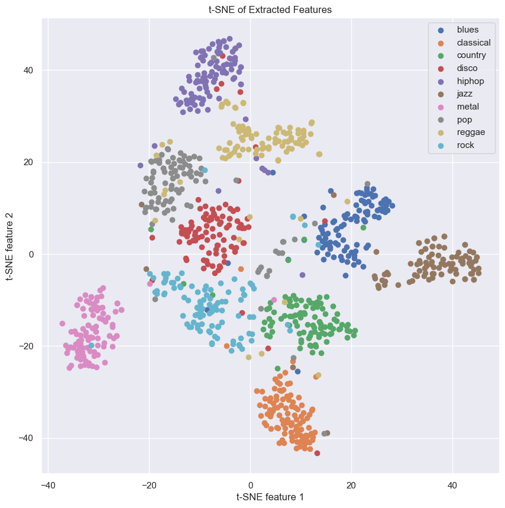

```python
genre_names = label_encoder.classes_

tsne = TSNE(n_components=2, random_state=42)
features_reduced = tsne.fit_transform(features)

# Step 4: Plot
plt.figure(figsize=(10, 10))

# Iterate over unique labels
for i, genre_name in enumerate(genre_names):
    idxs = labels == i  # Find indexes of samples with the current label
    plt.scatter(features_reduced[idxs, 0], features_reduced[idxs, 1], label=genre_name)

plt.legend()
plt.title('t-SNE of Extracted Features')
plt.xlabel('t-SNE feature 1')
plt.ylabel('t-SNE feature 2')
plt.show()
```

In the t-SNE visualization presented, each point represents a song, with its location corresponding to the extracted features reduced to two dimensions. The colors indicate different genres of music.

- **Cluster Formation**: Some genres, such as classical (in orange) and metal (in pink), form distinct clusters, which suggests that the features for songs in these genres have less variation within them and are distinctly different from features of songs in other genres. This indicates a high degree of separability based on the extracted features for these genres.
- **Overlap Between Genres**: Other genres, like rock (in cyan) and pop (in grey), show considerable overlap and are interspersed among various other genres. This overlap could imply that the characteristics of these genres are not as distinct in the feature space used or that there is a similarity in features among these overlapping genres.
- **Outliers and Spread**: There are noticeable outliers in several genres, which could either be indicative of some unique songs that are very different from their respective genre norms or could point towards mislabeled data or noise within the feature extraction process. Additionally, genres like reggae (in yellow) and rock (in cyan) have a broader spread, hinting at greater diversity within these genres as captured by the features.
- **Dense Regions**: Dense regions within clusters, such as those seen in the metal genre, suggest a high consistency in feature representation, which could be conducive to high classification accuracy for that genre.
- **Genre Ambiguities**: The interspersed nature of some genres could reflect the inherent ambiguity and subjective nature of music genre classification. For instance, sub-genres or music that bridges two genres could be causing this blend in the feature space.

In conclusion, the t-SNE plot provides valuable insights into the relationships between genres as captured by the model’s features. Clear clusters indicate a strong potential for accurate classification by the model, while overlap areas point to the need for more nuanced feature engineering or consideration of additional data to better capture the distinctions between genres. These observations can inform subsequent steps in model refinement and feature selection.

# How Does our Tutorial Compare to those that Exist for Music Genre Classification

Source1 [Creating a Music Genre Classifier using a Convolutional Neural Network](https://glenn-viroux.medium.com/creating-a-music-genre-classifier-using-a-convolutional-neural-network-548d06658cee)

Our tutorial takes a different approach to music genre classification compared to the method described in the source by Glenn Viroux. Both tutorials utilize the GTZAN dataset, which is a staple for genre classification tasks due to its diversity and suitability for benchmarking. However, the methodologies diverge significantly in terms of data preprocessing, network architecture, learning parameters, and audio sample size.

#### Data Preprocessing

- **Source1**: Converts audio samples into spectrograms using the librosa library, which is a common approach in audio processing tasks as it allows for customization in the conversion process and potential feature engineering.
- **Our Tutorial**: Uses pre-generated spectrogram images, which saves time and computational resources but offers less flexibility in terms of feature manipulation and extraction.

#### Network Architecture

- **Source1**: Employs a custom CNN architecture with a series of convolutional layers followed by max pooling and batch normalization, and a series of dense layers with dropout. This architecture is fairly standard for image-based CNNs and is known to extract features effectively from spectrogram data.
- **Our Tutorial**: Implements a ResNet architecture, specifically designed to enable the training of deeper neural networks by using skip connections to overcome the vanishing gradient problem. While more complex, ResNets are powerful in extracting hierarchical features and are often more scalable.

#### Learning Parameters

- **Source1**: Uses a smaller learning rate of 0.00005, which suggests a more cautious approach to updating weights, potentially requiring more epochs to converge but also providing fine-grained adjustments during learning.
- **Our Tutorial**: Chooses a learning rate of 0.001, which is more aggressive and can lead to faster convergence but may risk overshooting the optimal weights if not combined with an appropriate learning rate schedule or other regularization methods.

#### Batch Size and Audio Sample Size

- **Source1**: Opts for a smaller batch size of 32 and shorter audio clips of 4 seconds. Smaller batches can offer a regularizing effect and more frequent updates, but may increase training time. Shorter audio samples increase the amount of training data and can capture sufficient characteristics of music genres, but may miss longer-term structures within the music.
- **Our Tutorial**: Uses a larger batch size of 64 and full 30-second audio clips, potentially capturing more comprehensive musical features within each sample and providing a better approximation of the gradient during training, but may lead to longer training times per epoch.

#### Performance

- **Source1**: Achieves a final accuracy of 68%, which is respectable given the complexity of genre classification.
- **Our Tutorial**: Our CNN implementation reaches a higher accuracy of 77%, suggesting that the ResNet architecture and the choice of using full-length audio clips might be more effective for this task, despite the trade-offs mentioned.

### Pros and Cons

**Source1 Pros**:

- Customizable feature extraction via librosa
- Regularizing effects of smaller batch sizes
- Potential for detailed learning with smaller learning rate

**Source1 Cons**:

- Potentially less capable of learning deep features due to simpler architecture
- Shorter audio clips may miss important genre characteristics

**Our Tutorial Pros**:

- More powerful and deep ResNet architecture capable of capturing complex patterns
- Full-length audio clips could allow the model to learn from comprehensive musical structures

**Our Tutorial Cons**:

- Less flexibility in feature extraction from pre-generated spectrograms
- Larger batch sizes and longer audio clips could increase computational load

In conclusion, while both tutorials offer valid approaches to music genre classification, our ResNet-based method with full-length audio clips appears to outperform the custom CNN used in Source1 in terms of accuracy. This suggests that for tasks like music genre classification, where long-term structures may play a significant role, using deeper architectures and larger input sizes could be beneficial. However, the trade-off comes in the form of computational efficiency and training time, which are important considerations in a production setting.

### Comparative Analysis: Music Genre Classification Tutorials

Source2: https://www.analyticsvidhya.com/blog/2021/06/music-genres-classification-using-deep-learning-techniques/

Our tutorial's approach to music genre classification differs from Source2 in several fundamental ways, ranging from data preprocessing to model architecture and training parameters. Both tutorials employ the GTZAN dataset, which is popular for this type of task due to its established benchmark status.

#### Data Preprocessing and Input

- **Source2**: Utilizes the librosa library to convert audio samples into spectrograms dynamically. This method allows for real-time feature extraction, offering customization and potential fine-tuning based on the characteristics of the dataset.
- **Our Tutorial**: Uses pre-generated spectrogram images, streamlining the data preprocessing step and providing a consistent set of inputs for the model.

#### Network Architecture

- **Source2**: Employs a custom CNN architecture that consists of convolutional layers with max pooling and dropout layers for regularization, followed by a series of densely connected layers.
- **Our Tutorial**: Implements a ResNet model, a more complex but also more capable architecture in terms of learning deep feature hierarchies, which is particularly beneficial for capturing the nuances of audio data represented in spectrogram images.

#### Learning Parameters

- **Source2**: Chooses a lower learning rate of 0.0001, which is generally cautious and may require more epochs to converge, but provides more fine-grained weight updates. They compensate for this lower learning rate by training for 500 epochs.
- **Our Tutorial**: Uses a higher learning rate of 0.001, aiming for quicker convergence in a shorter time span, training the model for 100 epochs. While this may be faster, it requires careful monitoring to avoid potential overfitting or missing the global minimum.

#### Audio Sample Size

- **Source2**: Processes the full 30-second audio clips, mirroring our tutorial's approach. This allows both models to learn from the comprehensive audio content, capturing both the short-term and long-term temporal structures within the music.

#### Model Performance

- **Source2**: Achieves a lower accuracy of 52% with their CNN model, which might suggest that the architecture and training regimen were not fully optimized for the task.
- **Our Tutorial**: Our CNN implementation reaches a higher accuracy of 77%. This indicates that our chosen architecture and training parameters may be more suitable for this dataset and task.

### Pros and Cons

**Source2 Pros**:

- Custom feature extraction could potentially lead to more optimized spectrogram representations for the CNN.
- The lower learning rate and longer training time may yield a model finely tuned to the nuances of the data.
- Took 60 samples from each genre

**Source2 Cons**:

- The custom CNN architecture may not capture as complex features as a ResNet can, potentially limiting the achievable accuracy.
- The requirement for 500 epochs indicates a significant computational and time investment.

**Our Tutorial Pros**:

- The use of ResNet can leverage deep learning capabilities to capture complex patterns in the data.
- Pre-generated spectrograms and a larger batch size contribute to a more efficient training process in terms of time.

**Our Tutorial Cons**:

- A higher learning rate might risk overshooting the optimal weights and require careful tuning.
- Pre-generated features may lack the customization that real-time feature extraction with librosa can provide.
- Randomaly split the data 80/20 but could have taken 80 from each genre for a more accurate test and train data

# References List

- Andrada (n.d.). GTZAN Dataset - Music Genre Classification. [online] www.kaggle.com. Available at: https://www.kaggle.com/datasets/andradaolteanu/gtzan-dataset-music-genre-classification.
- Divakar (n.d.). crop center portion of a numpy image. [online] Stack Overflow. Available at: https://stackoverflow.com/questions/39382412/crop-center-portion-of-a-numpy-image [Accessed 17 Mar. 2024].
- docs.opencv.org. (n.d.). OpenCV: Contours : Getting Started. [online] Available at: https://docs.opencv.org/4.x/d4/d73/tutorial_py_contours_begin.html.
- Google (2022). Normalization. [online] Google Developers. Available at: https://developers.google.com/machine-learning/data-prep/transform/normalization.
- https://www.facebook.com/jason.brownlee.39 (2019). How to Manually Scale Image Pixel Data for Deep Learning. [online] Machine Learning Mastery. Available at: https://machinelearningmastery.com/how-to-manually-scale-image-pixel-data-for-deep-learning/.
- Nouman (2022). Writing ResNet from Scratch in PyTorch. [online] Paperspace Blog. Available at: https://blog.paperspace.com/writing-resnet-from-scratch-in-pytorch/.
- Oluyale, D. (2023). Detecting Musical Key from Audio Using Chroma Feature in Python. [online] Medium. Available at: https://medium.com/@oluyaled/detecting-musical-key-from-audio-using-chroma-feature-in-python-72850c0ae4b1 [Accessed 16 Mar. 2024].
- Opidi, A. and Jha, A. (2020). PyTorch Loss Functions: The Ultimate Guide. [online] neptune.ai. Available at: https://neptune.ai/blog/pytorch-loss-functions.
- pytorch.org. (n.d.). Datasets & DataLoaders — PyTorch Tutorials 1.11.0+cu102 documentation. [online] Available at: https://pytorch.org/tutorials/beginner/basics/data_tutorial.html.
- QuinnRadich (2022). Use PyTorch to train your data analysis model. [online] learn.microsoft.com. Available at: https://learn.microsoft.com/en-us/windows/ai/windows-ml/tutorials/pytorch-analysis-train-model [Accessed 17 Mar. 2024].
- Scikit-Learn (2019). sklearn.preprocessing.StandardScaler — scikit-learn 0.21.2 documentation. [online] Scikit-learn.org. Available at: https://scikit-learn.org/stable/modules/generated/sklearn.preprocessing.StandardScaler.html.
- scikit-learn (2018). sklearn.model_selection.train_test_split — scikit-learn 0.20.3 documentation. [online] Scikit-learn.org. Available at: https://scikit-learn.org/stable/modules/generated/sklearn.model_selection.train_test_split.html.
- T, D. (2019). Confusion Matrix Visualization. [online] Medium. Available at: https://medium.com/@dtuk81/confusion-matrix-visualization-fc31e3f30fea.
- Tam, A. (2023). Building Multilayer Perceptron Models in PyTorch. [online] Available at: https://machinelearningmastery.com/building-multilayer-perceptron-models-in-pytorch/.